# Exploring the Golf Digest and Golf Magazine Rankings

Ranking golf courses, like ranking colleges, is both a fool’s errand and a natural instinct, a pointless exercise as well as a major feather in the cap for courses across the country. Golfers can’t help but compare and contrast the courses they have played, and those comparisons can be quantified and sorted. Thanks to numerical rankings, however problematic they may be, over time can see changes in the way golf has been viewed and changes in how players value different course attributes and styles of architecture.

Until now, there hasn’t been an easily searchable and viewable way to explore the history of these rankings. Golf Digest and Golf Magazine do not make their data easily available and their data visualizations are practically nil. Visualizations and infographics are critical in allowing us to track trends over time, make links and associations, and generate clusters of similar courses.

Typos and incorrect information are almost assured; indeed, there is sometimes conflicting or missing information even within the same publication. Please feel free to send over corrections, fixes and suggestions to golfcourserankings@gmail.com.

Without further ado…

### Just show me the charts

- [Courses ranked on both lists (75 courses)](https://sperry304.github.io/ranked_in_both.html)
- [Courses ranked on one list (50 courses)](https://sperry304.github.io/ranked_in_one.html)

Or, if you want some guidance…

### [The blue bloods](https://sperry304.github.io/blue_bloods.html) (click the title to view individual charts)

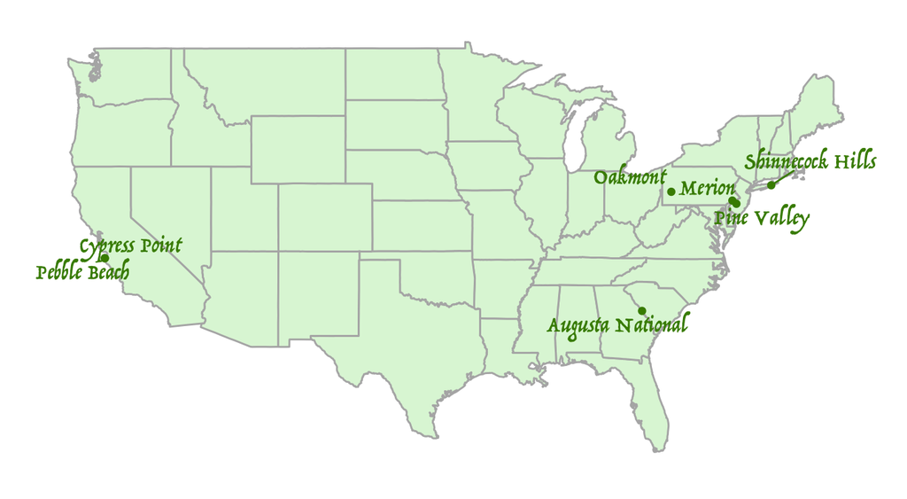

| Course | Location | Year Designed | Golf Digest | Golf Magazine | Average |
| --- | --- | --- | --- | --- | --- |
| Pine Valley | Pine Valley, NJ | 1918 | 1 | 1 | 1 |
| Augusta National | Augusta, GA | 1933 | 2 | 3 | 2.5 |
| Cypress Point | Pebble Beach, CA | 1928 | 3 | 2 | 2.5 |
| Shinnecock Hills | Southampton, NY | 1931 | 4 | 4 | 4 |
| Oakmont | Oakmont, PA | 1903 | 5 | 6 | 5.5 |
| Merion | Ardmore, PA | 1912 | 6 | 8 | 7 |
| Pebble Beach | Pebble Beach, CA | 1919 | 7 | 7 | 7 |

In both publications, the top 10 is rarefied air that has been occupied almost exclusively by a small number of classic courses built during golf’s [“golden age”](https://www.amazon.com/Golden-Age-Golf-Design/dp/1886947317) of design. The position of these tracks has not just been lofty, but also remarkably durable:

- Pine Valley (top 2 in every ranking in both publications)
- Cypress Point (top 5 in every ranking)
- Augusta National (top 5 in every ranking)
- Shinnecock Hills (top 6 in every ranking)
- Pebble Beach (top 7 in every ranking)
- Oakmont (top 8 in every ranking since 1993)
- Merion (top 8 in every ranking since 1995)

Golf Magazine’s ratings have been especially stable (ossified?) at the top - Pine Valley and Cypress Point have been ranked #1 and #2, respectively, in every edition since the first publication in 1991.

With the exception of Pebble Beach, membership rolls at these courses are populated by captains of industry and they are nearly impossible to get on for the average golfer. Interestingly, not all are tournament-ready - Pine Valley has never hosted professional events, Cypress Point pulled out of the Bing Crosby Clambake more than 30 years ago, and Merion only recently returned to the major championship rota - but the rest are current and former hosts of some of the most renowned and important competitions.

One noteworthy development in this largely static grouping is Golf Magazine putting Augusta National on notice with a column [disparaging the club’s recent design changes](https://www.golf.com/news/columns/2019/11/21/why-augusta-national-dropped-four-places-ranking/). Is Augusta’s perennial top 5 streak about to end? More importantly, like the Old Course at St. Andrews, are technological changes making these blue bloods obsolete for PGA Tour pros? (The answer is yes…)

### [The new (and newly revitalized) blue bloods](https://sperry304.github.io/new_blue_bloods.html)

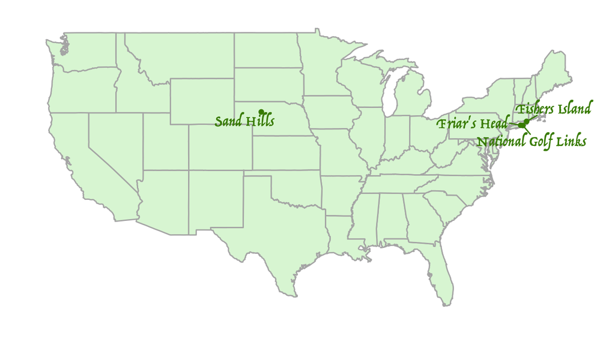

| Course | Location | Year Designed | Golf Digest | Golf Magazine | Average |
| --- | --- | --- | --- | --- | --- |
| National Golf Links | Southampton, NY | 1911 | 8 | 5 | 6.5 |
| Sand Hills | Mullen, NE | 1995 | 9 | 9 | 9 |
| Fishers Island | Fishers Island, NY | 1926 | 10 | 11 | 10.5 |
| Friar’s Head | Baiting Hollow, NY | 2002 | 15 | 21 | 18 |

At #9 in both rankings, Sand Hills’ standing is perhaps the most remarkable on the entire list. The highly influential 1995 Coore/Crenshaw design is more than 60 years newer than the second-youngest top 10 course (Augusta National, 1933) and it is the only course located between Oakmont on the east and Monterey on the west. Friar’s Head, another Coore/Crenshaw collaboration, is a borderline case for the blue blood label but deserves kudos for breaking into the top 15 in Golf Digest.

### [If this is the B-list, it’s quite the B-list](https://sperry304.github.io/b_list.html)

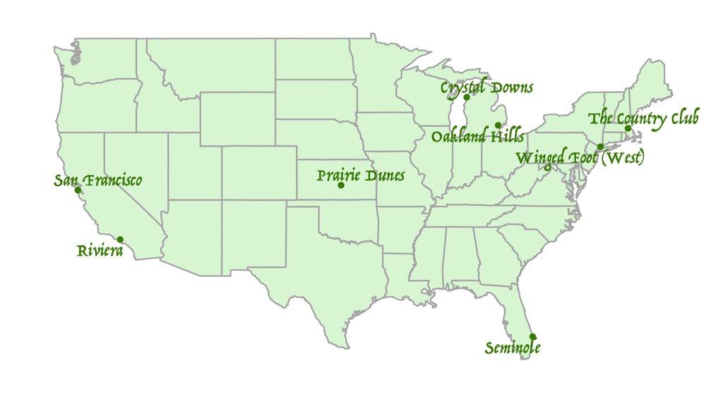

| Course | Location | Year Designed | Golf Digest | Golf Magazine | Average |
| --- | --- | --- | --- | --- | --- |
| Seminole | Juno Beach, FL | 1929 | 12 | 14 | 13 |
| Crystal Downs | Frankfort, MI | 1931 | 13 | 15 | 14 |
| Winged Foot (West) | Mamaroneck, NY | 1923 | 11 | 18 | 14.5 |
| The Country Club | Chestnut Hill, MA | 1895 | 18 | 22 | 20 |
| Riviera | Pacific Palisades, CA | 1926 | 23 | 20 | 21.5 |
| Oakland Hills | Bloomfield Hills, MI | 1918 | 20 | 24 | 22 |
| Prairie Dunes | Hutchinson, KS | 1937 | 27 | 19 | 23 |
| San Francisco | San Francisco, CA | 1924 | 35 | 16 | 25.5 |

The courses in this gorup have been mainstays in in the top 20 in one or the other of the two rankings, but they have consistently been placed one notch below the blue bloods. As before, there is a rough 50/50 split between major championship venues and clubs that have shunned the attention and inconvenience that tournaments bring.

### [Trouble in paradise, part 1: upper crust division](https://sperry304.github.io/trouble1.html)

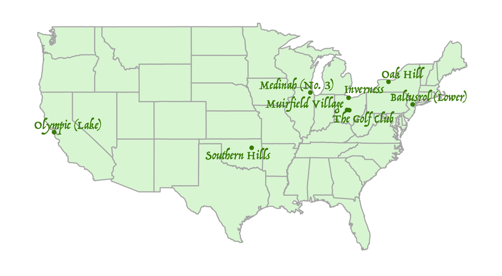

| Course | Location | Year Designed | Golf Digest | Golf Magazine | Average |
| --- | --- | --- | --- | --- | --- |
| Muirfield Village | Dublin, OH | 1974 | 16 | 29 | 22.5 |
| Oak Hill | Rochester, NY | 1925 | 22 | 43 | 32.5 |
| Olympic (Lake) | San Francisco, CA | 1924 | 33 | 33 | 33 |
| Southern Hills | Tulsa, OK | 1936 | 34 | 34 | 34 |
| Baltusrol (Lower) | Springfield, NJ | 1922 | 41 | 37 | 39 |
| The Golf Club | New Albany, OH | 1967 | 38 | 40 | 39 |
| Medinah (No. 3) | Medinah, IL | 1928 | 53 | 51 | 52 |
| Inverness | Toledo, OH | 1919 | 88 | 44 | 66 |

Of course anyone would love to belong to clubs like these, but the trend lines are undeniable. Will the negative movement continue or plateau? What’s causing the slide? If a problem can be identified, is it fixable, and if so, for how much money and time? Should members even care? It’s easy to say they shouldn’t, but it’s a tough pill to swallow, and bad for business, when your course drops 20, 30, or more places in the rankings table.

All the while, ghosts of magazines past haunt club boards:

- Shoal Creek, once ranked #11, out of both rankings
- Long Cove, once ranked #19, out of both rankings
- Laurel Valley, once ranked #22, out of both rankings
- Jupiter Hills, once ranked #23, out of both rankings
- Black Diamond Ranch, once ranked #24, out of both rankings

### [Returning to glory](https://sperry304.github.io/returners.html)

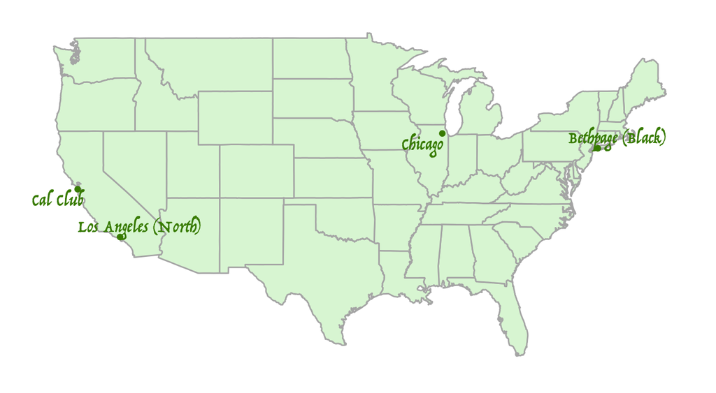

| Course | Location | Year Designed | Golf Digest | Golf Magazine | Average |
| --- | --- | --- | --- | --- | --- |
| Chicago | Wheaton, IL | 1894 | 14 | 12 | 13 |
| Los Angeles (North) | Los Angeles, CA | 1921 | 19 | 13 | 16 |
| Bethpage (Black) | Farmingdale, NY | 1936 | 37 | 23 | 30 |
| Cal Club | South San Francisco, CA | 1926 | - | 36 | - |

While a host of old-line courses have been muscled out of the top third of the charts, these clubs have been rewarded for renovation work by trendy architects and/or publicity bumps after hosting major amateur and professional events. This list of comeback kids is not a long one even if you add National, Fishers Island, or the small number of other classic courses that have managed to make moves back into the top half of the rankings.

### [A few merely fantastic courses that you also won’t be able to get on (old school)](https://sperry304.github.io/fantastic1.html)

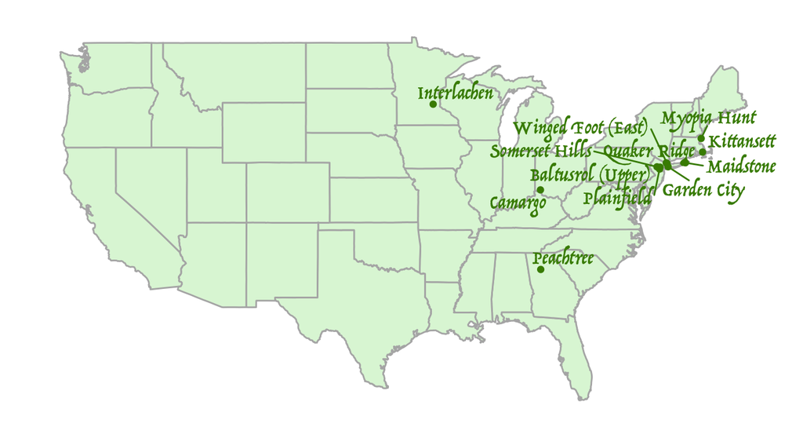

| Course | Location | Year Designed | Golf Digest | Golf Magazine | Average |
| --- | --- | --- | --- | --- | --- |
| Camargo | Indian Hill, OH | 1927 | 44 | 31 | 37.5 |
| Garden City | Garden City, NY | 1899 | 51 | 26 | 38.5 |
| Peachtree | Atlanta, GA | 1947 | 30 | 49 | 39.5 |
| Winged Foot (East) | Mamaroneck, NY | 1923 | 52 | 41 | 46.5 |
| Somerset Hills | Bernardsville, NJ | 1918 | 63 | 38 | 50.5 |
| Maidstone | East Hampton, NY | 1924 | 67 | 35 | 51 |
| Quaker Ridge | Scarsdale, NY | 1918 | 71 | 39 | 55 |
| Interlachen | Edina, MN | 1911 | 58 | 75 | 66.5 |
| Myopia Hunt | South Hamilton, MA | 1898 | 76 | 63 | 69.5 |
| Plainfield | Edison, NJ | 1921 | 82 | 60 | 71 |
| Baltusrol (Upper) | Springfield, NJ | 1922 | 61 | 83 | 72 |
| Kittansett | Marion, MA | 1922 | 78 | 66 | 72 |

These highly rated private clubs, all but one east of the Mississippi River (and Interlachen only barely west), tend to fall in the 40-80 range and are showing stability and staying power. All of them were designed in the 1920s and earlier except Peachtree, which gets honorary “golden age” status from the Bobby Jones connection.

### [A few merely fantastic courses that you also won’t be able to get on (new school)](https://sperry304.github.io/fantastic2.html)

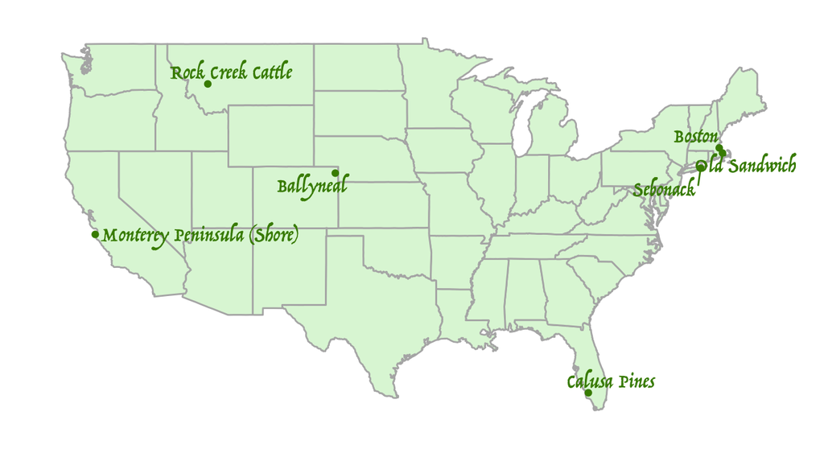

| Course | Location | Year Designed | Golf Digest | Golf Magazine | Average |
| --- | --- | --- | --- | --- | --- |
| Ballyneal | Holyoke, CO | 2006 | 46 | 42 | 44 |
| Old Sandwich | Plymouth, MA | 2005 | 59 | 50 | 54.5 |
| Sebonack | Southampton, NY | 2006 | 39 | 76 | 57.5 |
| Monterey Peninsula (Shore) | Pebble Beach, CA | 2004 | 56 | 67 | 61.5 |
| Calusa Pines | Naples, FL | 2001 | 83 | 91 | 87 |
| Boston | Hingham, MA | 2004 | 87 | 88 | 87.5 |
| Rock Creek Cattle | Deer Lodge, MT | 2008 | - | 65 | - |

I’m accepting invitations…

### [The cheapest dates on the list](https://sperry304.github.io/cheap.html)

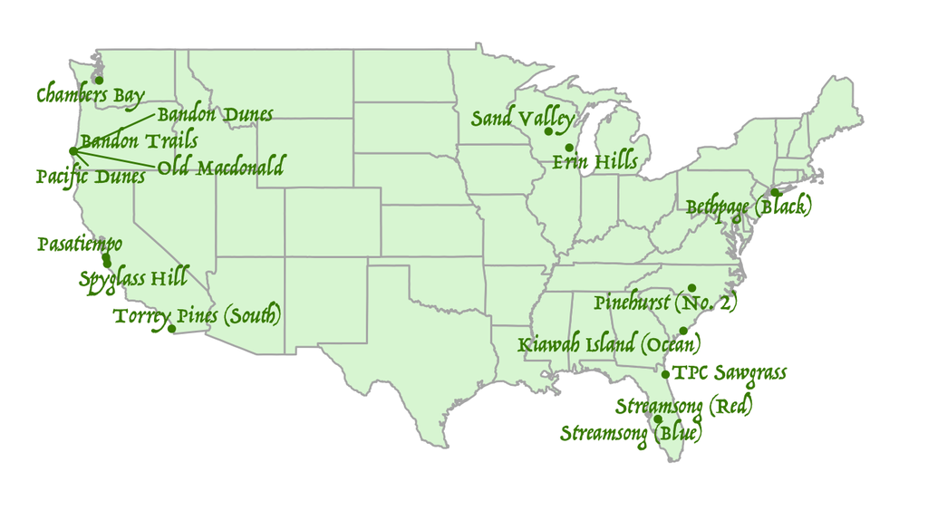

| Course | Location | Year Designed | Golf Digest | Golf Magazine | Average |
| --- | --- | --- | --- | --- | --- |
| Pacific Dunes | Bandon, OR | 2001 | 17 | 17 | 17 |
| Pinehurst (No. 2) | Pinehurst, NC | 1935 | 29 | 10 | 19.5 |
| Kiawah Island (Ocean) | Kiawah Island, SC | 1991 | 24 | 25 | 24.5 |
| Bethpage (Black) | Farmingdale, NY | 1936 | 37 | 23 | 30 |
| Bandon Dunes | Bandon, OR | 1999 | 36 | 32 | 34 |
| TPC Sawgrass | Ponte Vedra Beach, FL | 1980 | 49 | 30 | 39.5 |
| Spyglass Hill | Pebble Beach, CA | 1966 | 45 | 54 | 49.5 |
| Old Macdonald | Bandon, OR | 2010 | 50 | 57 | 53.5 |
| Bandon Trails | Bandon, OR | 2005 | 69 | 46 | 57.5 |
| Erin Hills | Erin, WI | 2006 | 42 | 74 | 58 |
| Streamsong (Red) | Streamsong, FL | 2012 | - | 47 | - |
| Sand Valley | Nekoosa, WI | 2017 | - | 52 | - |
| Pasatiempo | Santa Cruz, CA | 1929 | - | 53 | - |
| Streamsong (Blue) | Streamsong, FL | 2012 | - | 64 | - |
| Torrey Pines (South) | La Jolla, CA | 1957 | - | 87 | - |
| Chambers Bay | University Place, WA | 2007 | - | 98 | - |

Good news, comrades! Not all of the top 100 is stacked with stuffy, expensive private clubs - there are also some stuffy, expensive public courses as well. But remember, $400 for a round of golf is a hell of a lot less expensive than $100,000 for initiation fees.

The Bandon group is obviously the #1 target here, but after that I would set up shop at Bethpage, the unholy union of Pine Valley and the DMV.

Interestingly, every public course ranked by Golf Digest is ranked by Golf Magazine but not vice versa. It’s one thing to sniff your nose at Streamsong or Torrey Pines, but Pasatiempo?

### [Tom Fazio’s checks to the Golf Magazine raters apparently didn’t clear](https://sperry304.github.io/fazio.html)

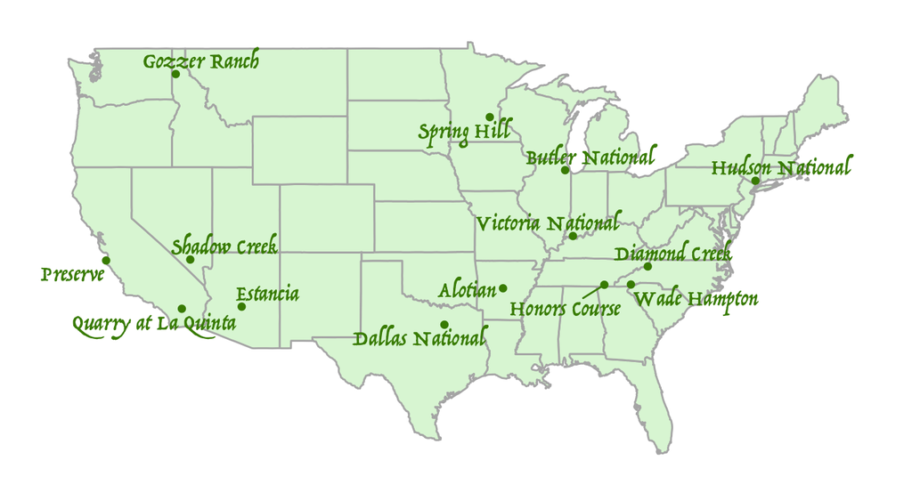

| Course | Location | Year Designed | Golf Digest | Golf Magazine | Average |
| --- | --- | --- | --- | --- | --- |
| Wade Hampton | Cashiers, NC | 1987 | 25 | 58 | 41.5 |
| Shadow Creek | North Las Vegas, NV | 1990 | 26 | 61 | 43.5 |
| Honors Course | Ooltewah, TN | 1983 | 28 | 78 | 53 |
| Gozzer Ranch | Harrison, ID | 2007 | 32 | 95 | 63.5 |
| Alotian | Roland, AK | 2004 | 31 | - | - |
| Victoria National | Newburgh, IN | 1998 | 43 | - | - |
| Butler National | Oak Brook, IL | 1974 | 47 | - | - |
| Dallas National | Dallas, TX | 2002 | 65 | - | - |
| Estancia | Scottsdale, AZ | 1995 | 70 | - | - |
| Quarry at La Quinta | La Quinta, CA | 1994 | 77 | - | - |
| Hudson National | Croton-on-Hudson, NY | 1996 | 81 | - | - |
| Diamond Creek | Banner Elk, NC | 2003 | 90 | - | - |
| Spring Hill | Wayzata, MN | 1999 | 93 | - | - |
| Preserve | Carmel, CA | 2000 | 96 | - | - |

The Fazio aesthetic represents the clearest difference between the two magazines. Golf Digest loves it, Golf Magazine doesn’t. Alotian was once #14 in Golf Digest (now #31) and is unranked in Golf Magazine, with Gozzer Ranch about to meet a similar fate. Props to anyone who has actually heard of all of these courses, let alone played them.

### [A few more lush, luxurious tracks that Golf Digest loves and Golf Magazine doesn’t (non-Fazio edition)](https://sperry304.github.io/lush.html)

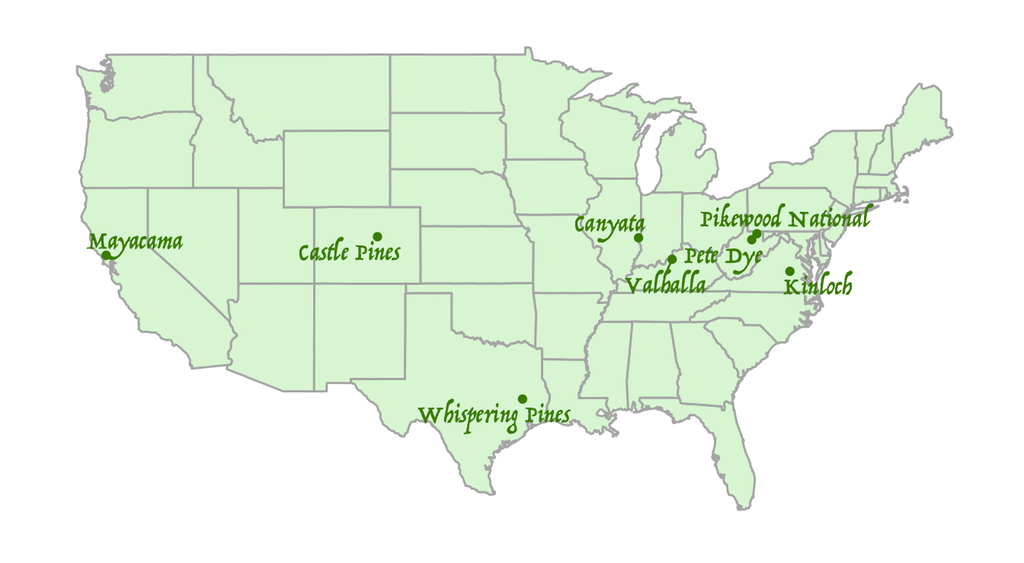

| Course | Location | Year Designed | Golf Digest | Golf Magazine | Average |
| --- | --- | --- | --- | --- | --- |
| Pikewood National | Morgantown, WV | 2009 | 40 | - | - |
| Castle Pines | Castle Rock, CO | 1981 | 48 | - | - |
| Whispering Pines | Trinity, TX | 2000 | 54 | - | - |
| Canyata | Marshall, IL | 2004 | 62 | - | - |
| Pete Dye | Bridgeport, WV | 1994 | 64 | - | - |
| Kinloch | Manakin-Sabot, VA | 2001 | 66 | - | - |
| Valhalla | Louisville, KY | 1986 | 84 | - | - |
| Mayacama | Santa Rosa, CA | 2001 | 100 | - | - |

Some of these could also be placed in the “trouble in paradise” category…

### [Some ancient clubs that Golf Magazine loves and Golf Digest doesn’t](https://sperry304.github.io/ancient.html)

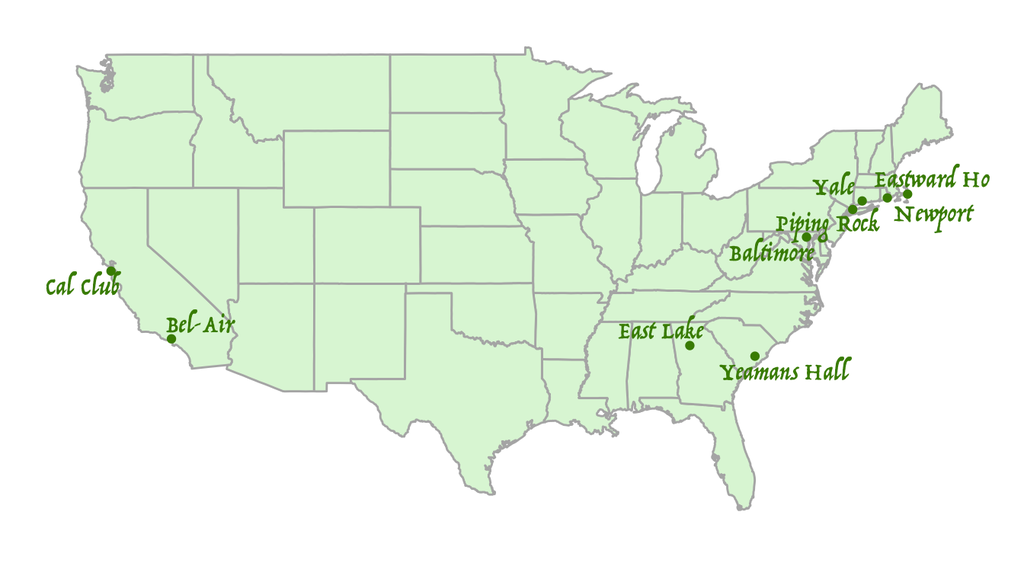

| Course | Location | Year Designed | Golf Digest | Golf Magazine | Average |
| --- | --- | --- | --- | --- | --- |
| Yeamans Hall | Charleston, SC | 1926 | 95 | 56 | 75.5 |
| Cal Club | South San Francisco, CA | 1926 | - | 36 | - |
| Yale | New Haven, CT | 1923 | - | 55 | - |
| Eastward Ho | Chatham, MA | 1922 | - | 62 | - |
| Piping Rock | Locust Valley, NY | 1913 | - | 69 | - |
| East Lake | Atlanta, GA | 1915 | - | 70 | - |
| Newport | Newport, RI | 1899 | - | 71 | - |
| Baltimore | Lutherville, MD | 1926 | - | 72 | - |
| Bel-Air | Los Angeles, CA | 1926 | - | 80 | - |

I haven’t played most of these courses, but the prospect of a post-round clubhouse tour of priceless memorabilia makes them much more appealing than the Fazio/Nicklaus/Dye Golf Digest set.

### [Back in vogue, for now at least](https://sperry304.github.io/vogue.html)

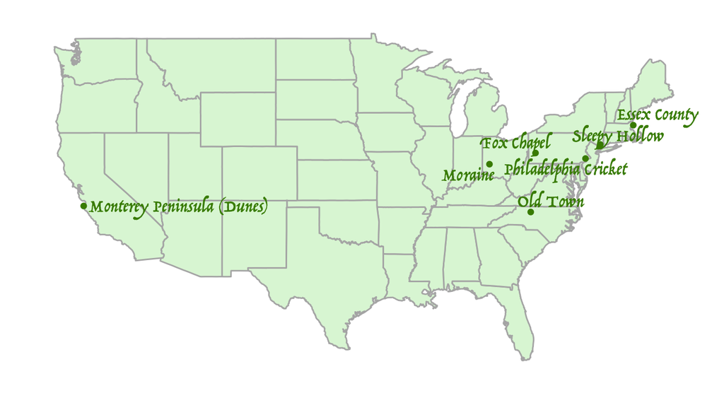

| Course | Location | Year Designed | Golf Digest | Golf Magazine | Average |
| --- | --- | --- | --- | --- | --- |
| Essex County | Manchester, MA | 1917 | 73 | 82 | 77.5 |
| Old Town | Winston-Salem, NC | 1939 | 98 | 59 | 78.5 |
| Monterey Peninsula (Dunes) | Pebble Beach, CA | 1924 | 79 | 94 | 86.5 |
| Sleepy Hollow | Briarcliff Manor, NY | 1915 | 89 | 96 | 92.5 |
| Fox Chapel | Pittsburgh, PA | 1926 | - | 81 | - |
| Philadelphia Cricket | Flourtown, PA | 1922 | - | 86 | - |
| Moraine | Dayton, OH | 1930 | - | 89 | - |

These classic courses have recently returned to the rankings; time will tell whether they have staying power.

### [Trouble in paradise, part 2: catch the falling knife](https://sperry304.github.io/trouble2.html)

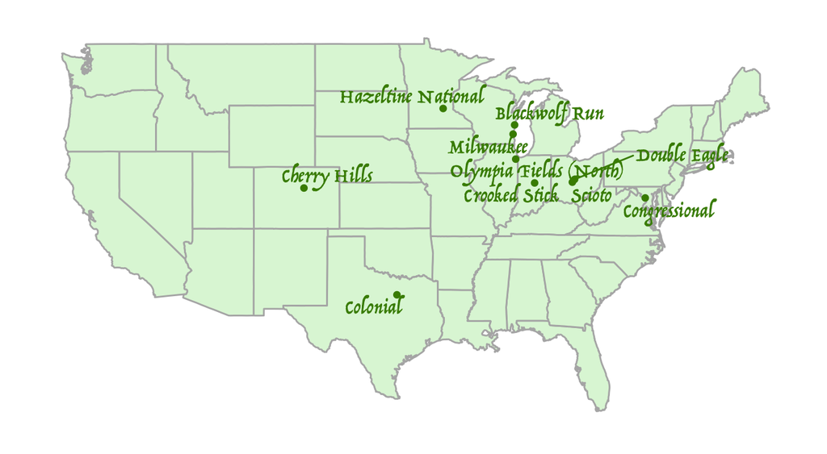

| Course | Location | Year Designed | Golf Digest | Golf Magazine | Average |
| --- | --- | --- | --- | --- | --- |
| Scioto | Columbus, OH | 1916 | 57 | 79 | 68 |
| Cherry Hills | Cherry Hills Village, CO | 1923 | 72 | 73 | 72.5 |
| Congressional | Bethesda, MD | 1962 | 80 | 77 | 78.5 |
| Milwaukee | River Hills, WI | 1929 | 74 | 84 | 79 |
| Blackwolf Run | Kohler, WI | 1990 | 97 | 100 | 98.5 |
| Olympia Fields (North) | Olympia Fields, IL | 1922 | 75 | - | - |
| Colonial | Fort Worth, TX | 1936 | - | 92 | - |
| Double Eagle | Galena, OH | 1992 | 92 | - | - |
| Hazeltine National | Chaska, MN | 1962 | - | 93 | - |
| Crooked Stick | Carmel, IN | 1967 | 99 | - | - |

With the fierce competition in the golf course market, declining demand for country club memberships, and unpredictable, shifting architectural tastes across a variety of different constituencies, efforts to stay in the Top 100 will be expensive - and might not even work. Good luck!

### [Hanging on by a thread](https://sperry304.github.io/thread.html)

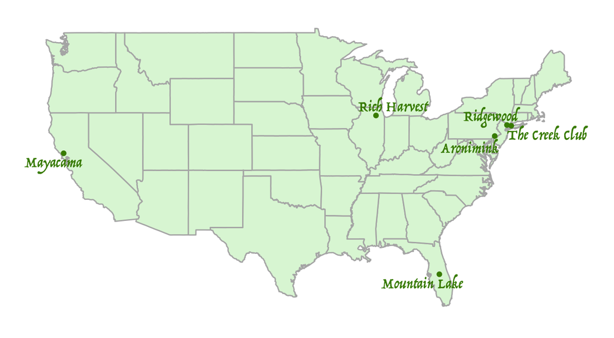

| Course | Location | Year Designed | Golf Digest | Golf Magazine | Average |
| --- | --- | --- | --- | --- | --- |
| Aronimink | Newtown Square, PA | 1928 | 85 | 97 | 91 |
| Ridgewood | Paramus, NJ | 1929 | - | 85 | - |
| The Creek Club | Locust Valley, NY | 1923 | - | 90 | - |
| Rich Harvest | Sugar Grove, IL | 1999 | 94 | - | - |
| Mountain Lake | Lake Wales, FL | 1921 | - | 99 | - |
| Mayacama | Santa Rosa, CA | 2001 | 100 | - | - |